# Project - US Homicide Statistics Analysis

### Load Libraries

```r
library(tidyverse)
```

```r
library(ggplot2)
library(skimr)
library(scales)
library(wesanderson)
```

### Load Dataset

```r
homicide_stats <- read_csv("HomicideStats.csv")
```

### Summary of Data

```r
skim(homicide_stats)
```

Data summary

| Name | homicide_stats |
| --- | --- |
| Number of rows | 638454 |
| Number of columns | 24 |
| _______________________ |  |
| Column type frequency: |  |
| character | 18 |
| numeric | 6 |
| ________________________ |  |
| Group variables | None |

**Variable type: character**

| skim_variable | n_missing | complete_rate | min | max | empty | n_unique | whitespace |
| --- | --- | --- | --- | --- | --- | --- | --- |
| Record ID | 0 | 1 | 6 | 6 | 0 | 638454 | 0 |
| Agency Code | 0 | 1 | 7 | 7 | 0 | 12003 | 0 |
| Agency Name | 0 | 1 | 3 | 81 | 0 | 9216 | 0 |
| Agency Type | 0 | 1 | 7 | 16 | 0 | 7 | 0 |
| City | 0 | 1 | 3 | 31 | 0 | 1782 | 0 |
| State | 0 | 1 | 4 | 20 | 0 | 51 | 0 |
| Month | 0 | 1 | 3 | 9 | 0 | 12 | 0 |
| Crime Type | 0 | 1 | 22 | 26 | 0 | 2 | 0 |
| Crime Solved | 0 | 1 | 2 | 3 | 0 | 2 | 0 |
| Victim Sex | 0 | 1 | 4 | 7 | 0 | 3 | 0 |
| Victim Race | 0 | 1 | 5 | 29 | 0 | 5 | 0 |
| Victim Ethnicity | 0 | 1 | 7 | 12 | 0 | 3 | 0 |
| Perpetrator Sex | 0 | 1 | 4 | 7 | 0 | 3 | 0 |
| Perpetrator Race | 0 | 1 | 5 | 29 | 0 | 5 | 0 |
| Perpetrator Ethnicity | 0 | 1 | 7 | 12 | 0 | 3 | 0 |
| Relationship | 0 | 1 | 3 | 20 | 0 | 28 | 0 |
| Weapon | 0 | 1 | 3 | 13 | 0 | 16 | 0 |
| Record Source | 0 | 1 | 3 | 4 | 0 | 2 | 0 |

**Variable type: numeric**

| skim_variable | n_missing | complete_rate | mean | sd | p0 | p25 | p50 | p75 | p100 | hist |
| --- | --- | --- | --- | --- | --- | --- | --- | --- | --- | --- |
| Year | 0 | 1 | 1995.80 | 9.93 | 1980 | 1987 | 1995 | 2004 | 2014 | ▇▇▇▆▆ |
| Incident | 0 | 1 | 22.97 | 92.15 | 0 | 1 | 2 | 10 | 999 | ▇▁▁▁▁ |
| Victim Age | 0 | 1 | 35.03 | 41.63 | 0 | 22 | 30 | 42 | 998 | ▇▁▁▁▁ |
| Perpetrator Age | 1 | 1 | 20.32 | 17.89 | 0 | 0 | 21 | 31 | 99 | ▇▇▂▁▁ |
| Victim Count | 0 | 1 | 0.12 | 0.54 | 0 | 0 | 0 | 0 | 10 | ▇▁▁▁▁ |
| Perpetrator Count | 0 | 1 | 0.19 | 0.59 | 0 | 0 | 0 | 0 | 10 | ▇▁▁▁▁ |

```r
summary(homicide_stats)
```

```
##   Record ID         Agency Code        Agency Name        Agency Type
##  Length:638454      Length:638454      Length:638454      Length:638454
##  Class :character   Class :character   Class :character   Class :character
##  Mode  :character   Mode  :character   Mode  :character   Mode  :character
##
##
##
##
##      City              State                Year         Month
##  Length:638454      Length:638454      Min.   :1980   Length:638454
##  Class :character   Class :character   1st Qu.:1987   Class :character
##  Mode  :character   Mode  :character   Median :1995   Mode  :character
##                                        Mean   :1996
##                                        3rd Qu.:2004
##                                        Max.   :2014
##
##     Incident       Crime Type        Crime Solved        Victim Sex
##  Min.   :  0.00   Length:638454      Length:638454      Length:638454
##  1st Qu.:  1.00   Class :character   Class :character   Class :character
##  Median :  2.00   Mode  :character   Mode  :character   Mode  :character
##  Mean   : 22.97
##  3rd Qu.: 10.00
##  Max.   :999.00
##
##    Victim Age     Victim Race        Victim Ethnicity   Perpetrator Sex
##  Min.   :  0.00   Length:638454      Length:638454      Length:638454
##  1st Qu.: 22.00   Class :character   Class :character   Class :character
##  Median : 30.00   Mode  :character   Mode  :character   Mode  :character
##  Mean   : 35.03
##  3rd Qu.: 42.00
##  Max.   :998.00
##
##  Perpetrator Age Perpetrator Race   Perpetrator Ethnicity Relationship
##  Min.   : 0.00   Length:638454      Length:638454         Length:638454
##  1st Qu.: 0.00   Class :character   Class :character      Class :character
##  Median :21.00   Mode  :character   Mode  :character      Mode  :character
##  Mean   :20.32
##  3rd Qu.:31.00
##  Max.   :99.00
##  NA's   :1
##     Weapon           Victim Count     Perpetrator Count Record Source
##  Length:638454      Min.   : 0.0000   Min.   : 0.0000   Length:638454
##  Class :character   1st Qu.: 0.0000   1st Qu.: 0.0000   Class :character
##  Mode  :character   Median : 0.0000   Median : 0.0000   Mode  :character
##                     Mean   : 0.1233   Mean   : 0.1852
##                     3rd Qu.: 0.0000   3rd Qu.: 0.0000
##                     Max.   :10.0000   Max.   :10.0000
##
```

### Univariate Numerical - Crime Rate over the time period

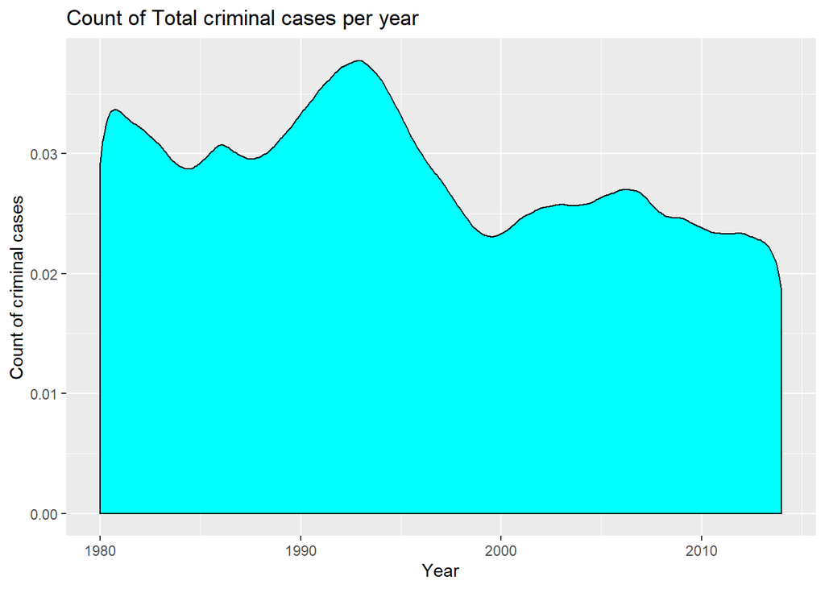

```r
homicide_stats %>%
  ggplot(aes(x = Year))+
  geom_density(fill = "cyan", color = "black")+
  labs(title = "Count of Total criminal cases per year",
       x = "Year",
       y = "Count of criminal cases")
```

```r
homicide_stats %>%
  group_by(Year) %>%
  mutate(Count = n()) %>%
  select(Year, Count) %>%
  distinct()
```

| Year | Count |
| --- | --- |
| 1980 | 23092 |
| 1981 | 21208 |
| 1982 | 20544 |
| 1983 | 19653 |
| 1984 | 18093 |
| 1985 | 18386 |
| 1986 | 20125 |
| 1987 | 18783 |
| 1988 | 18779 |
| 1989 | 19868 |

[output cut: 25 more lines]

```r
# homicide_stats %>%
#   ggplot(aes(x = Year, fill = State))+
#   geom_histogram()+
#   labs(title = "Count of Total criminal cases per year",
#        x = "Year",
#        y = "Count of criminal cases")
```

### Univariate Categorical (three different years - min, median, max)

### Count of criminal cases per State for different years

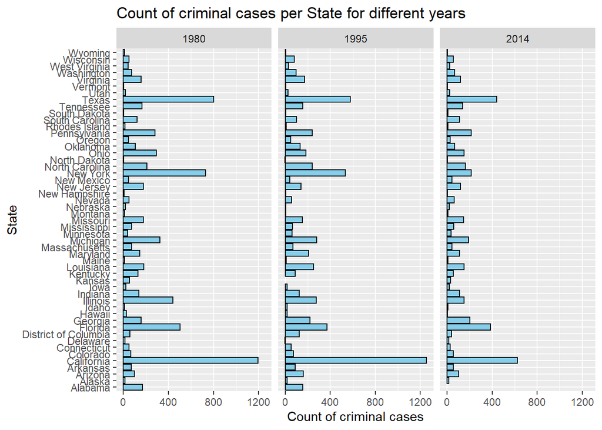

```r
homicide_stats %>%
  filter(Year == c(min(Year), median(Year), max(Year))) %>%
  ggplot(aes(x = State))+
  geom_bar(fill = "skyblue", color = "black")+
  facet_grid( ~ (Year))+
  coord_flip()+
  labs(title = "Count of criminal cases per State for different years",
       x = "State",
       y = "Count of criminal cases")
```

### Univariate Categorical - Most Preferred Weapon from 1980-2014

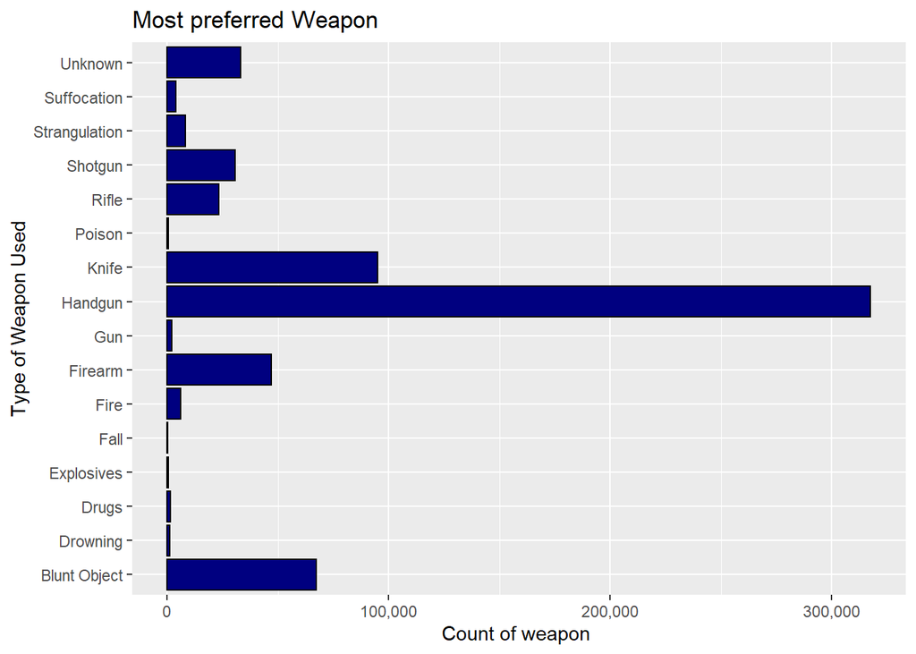

```r
homicide_stats %>%
  ggplot(aes(x = Weapon, y = ..count..))+
  geom_bar(fill = "navyblue", color = "black")+
  coord_flip()+
  labs(title = "Most preferred Weapon",
       x = "Type of Weapon Used",
       y = "Count of weapon ")+
  scale_y_continuous(labels = comma)
```

### Univariate Analysis Numerical - Which age group below 15 years is most victimised?

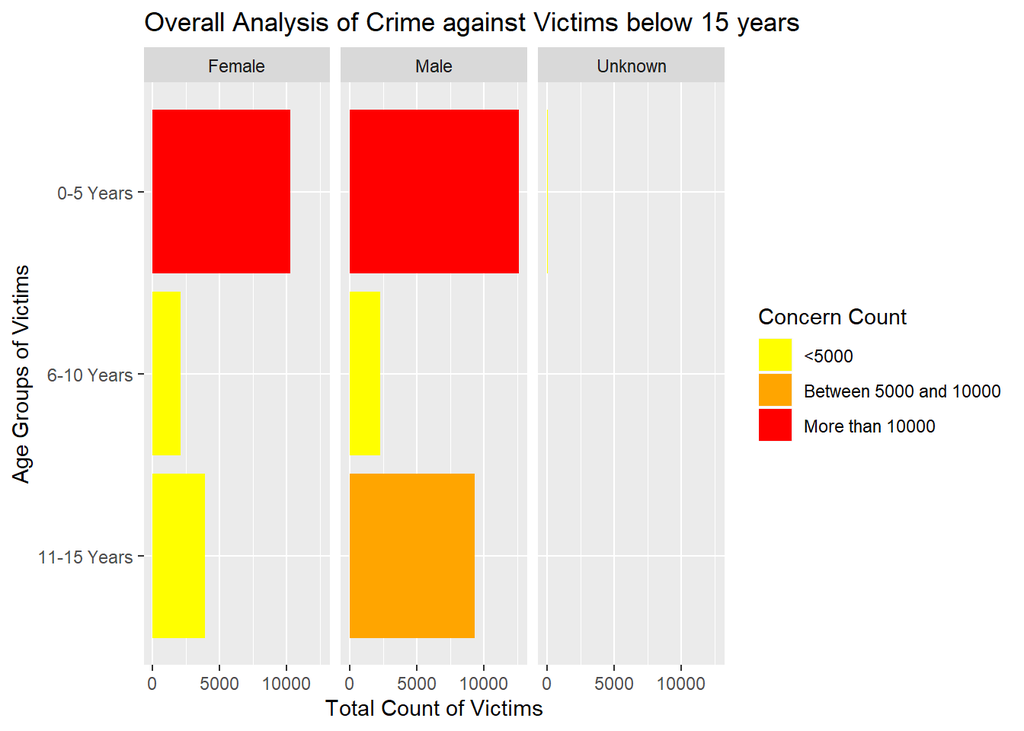

```r
homicide_stats_age15 <- homicide_stats %>%
  filter(`Victim Age` <= 15) %>%
  mutate(age_group = cut(`Victim Age`, breaks=c(0,5,10,15), include.lowest = T, labels = c("0-5 Years", "6-10 Years", "11-15 Years")))

homicide_stats_age15 <- homicide_stats_age15 %>%
  group_by(age_group, `Victim Sex`) %>%
  mutate(count = n(),
         `Concern Count` = cut(count, breaks = c(0,5000,10000,15000), include.lowest = T, labels = c("<5000","Between 5000 and 10000","More than 10000")))

#palette
pal <- c("<5000" = "yellow",
         "Between 5000 and 10000" = "orange",
         "More than 10000" = "red")

homicide_stats_age15 %>%
  filter(!is.na(age_group)) %>%
  ggplot(aes(x = age_group, fill = `Concern Count`))+
  geom_bar()+
  facet_grid( ~ `Victim Sex`)+
  labs(title = "Overall Analysis of Crime against Victims below 15 years",
       x = "Age Groups of Victims",
       y = "Total Count of Victims")+
  coord_flip()+
  scale_x_discrete(limits = rev(levels(homicide_stats_age15$age_group))) +
  scale_fill_manual(
    values = pal,
    limits = names(pal))
```

### Count of Criminal Cases per State for different decades

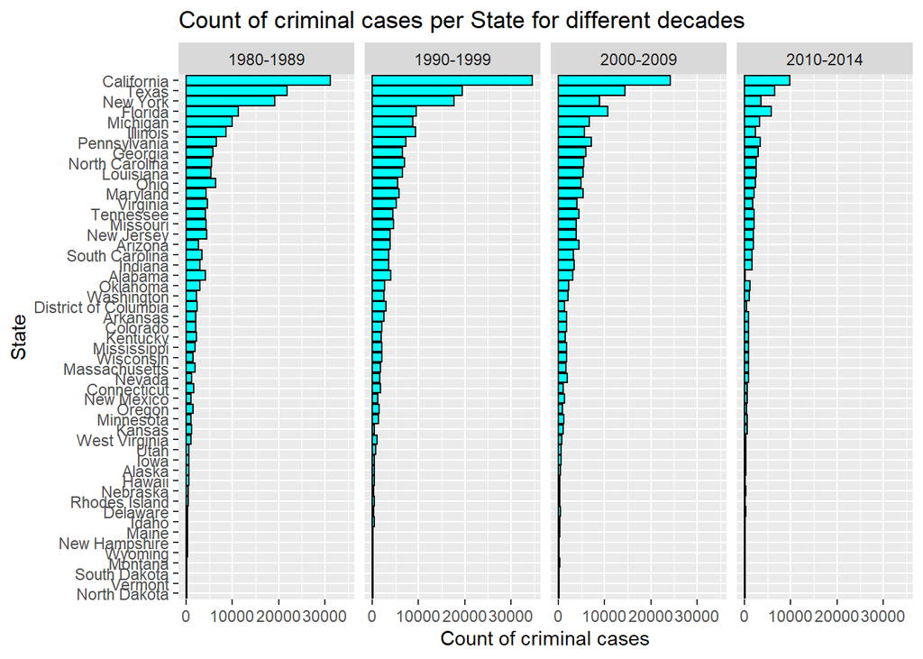

```r
#library(forcats)
homicide_stats_decade <- homicide_stats %>%
  mutate(decade = cut(Year, breaks = c(1980,1989,1999,2009,2014), include.lowest = T, labels = c("1980-1989","1990-1999","2000-2009","2010-2014")))

homicide_stats_decade_order <- homicide_stats_decade %>%
  select(State, decade) %>%
  group_by(State,decade) %>%
  mutate(Count = n()) %>%
  distinct()

homicide_stats_decade_order %>%
  #mutate(Count = fct_reorder(State,desc(Count))) %>%
  ggplot(aes(x = reorder(State, Count), y = Count))+
  geom_bar(stat = "identity", fill = "cyan", color = "black")+
  coord_flip()+
  facet_grid( ~ decade)+
  labs(title = "Count of criminal cases per State for different decades",
       x = "State",
       y = "Count of criminal cases")
```

### Victim Race Crime Analysis

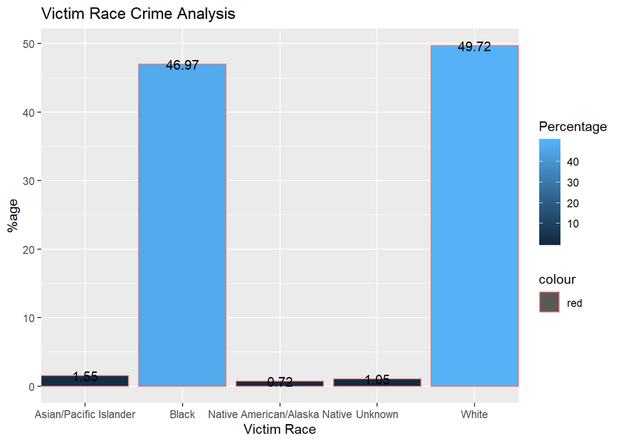

```r
homicide_stats_victim <- homicide_stats %>%
  mutate(Total = n()) %>%
  group_by(`Victim Race`) %>%
  select(`Victim Race`, Total) %>%
  mutate(Count = n()) %>%
  mutate(Percentage = round(Count*100/Total,2)) %>%
  distinct()

# Gradient color
#grad <- wes_palette("Zissou1", 100, type = "continuous")

homicide_stats_victim %>%
  ggplot(aes(x = `Victim Race`, y = Percentage))+
  geom_bar(stat = "identity", aes(fill = Percentage, color = "red"))+
  geom_text(aes(label = Percentage))+
  labs(title = "Victim Race Crime Analysis",
       x = "Victim Race",
       y = "%age")+
   scale_x_discrete(expand = c(0, 0)) #+
```

```r
   #scale_y_discrete(expand = c(0, 0)) +
   #coord_equal()
```

### Bivariate Analysis (Categorical+Categorical)

### Victim Race vs Perpetrator Race Crime Analysis

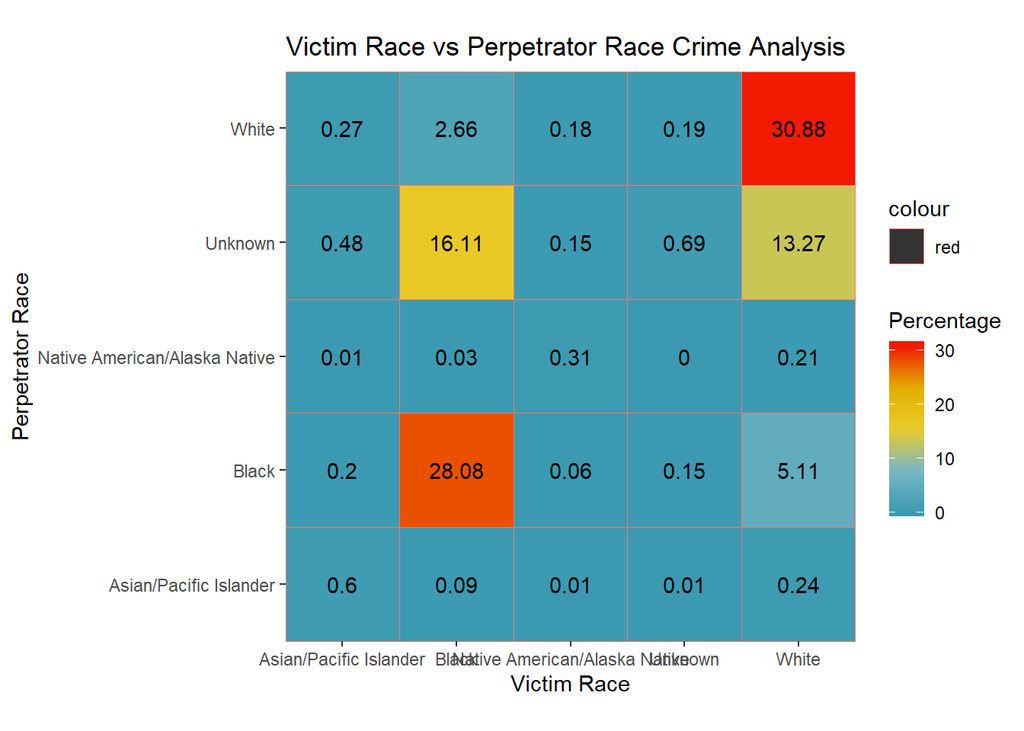

```r
homicide_stats_race <- homicide_stats %>%
  mutate(Total = n()) %>%
  group_by(`Victim Race`,`Perpetrator Race`) %>%
  select(`Victim Race`,`Perpetrator Race`, Total) %>%
  mutate(Count = n()) %>%
  mutate(Percentage = round(Count*100/Total,2)) %>%
  distinct()

# Gradient color
grad <- wes_palette("Zissou1", 100, type = "continuous")

homicide_stats_race %>%
  ggplot(aes(x = `Victim Race`, y = `Perpetrator Race`))+
  geom_tile(aes(fill = Percentage, color = "red"))+
  geom_text(aes(label = Percentage))+
  labs(title = "Victim Race vs Perpetrator Race Crime Analysis",
       x = "Victim Race",
       y = "Perpetrator Race")+
  scale_fill_gradientn(colours = grad) +
  scale_x_discrete(expand = c(0, 0)) +
  scale_y_discrete(expand = c(0, 0)) +
  coord_equal()
```

### Analysis of Crime Solving Rate of various Agencies

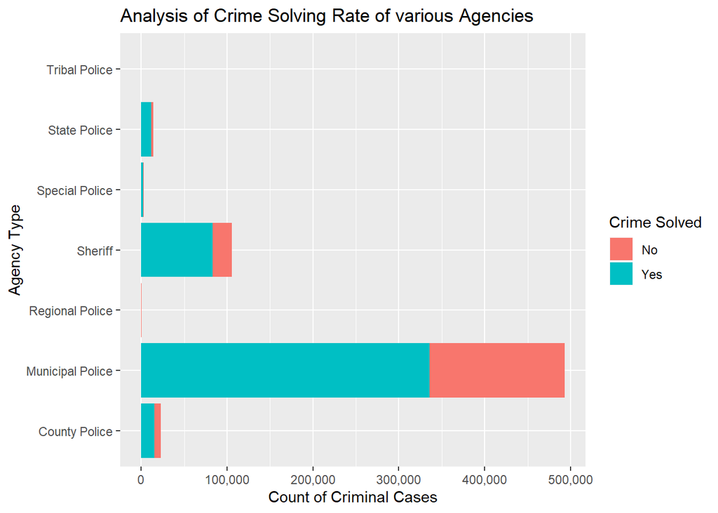

```r
homicide_stats_t <- homicide_stats %>%
  group_by(`Agency Type`,`Crime Solved`) %>%
  select(`Agency Type`,`Crime Solved`) %>%
  mutate(Count = n()) %>%
  distinct()


homicide_stats_t %>%
  ggplot(aes(x = `Agency Type`, y = Count, fill = `Crime Solved`))+
  geom_bar(stat = "identity")+
  coord_flip()+
  labs(title = "Analysis of Crime Solving Rate of various Agencies",
       x = "Agency Type",
       y = "Count of Criminal Cases")+
  scale_y_continuous(labels = comma)
```

### Conclusion

1. On analysis, we have found out that the crime was prevalent in 1990s. Post that, we have decline in the crime rate.
2. From 1980 to 2014, California is the leading state when it comes to crime, which is followed by Texas.
3. Handgun is the most accessible weapon and thus, is used most in the criminal activities.
4. Below 15 years, most of the criminal cases are reported in case of children between 0-5 years of age for both males and females.
5. First two decades of the dataset, i.e., 1980-1989 and 1990-1999 have the highest crime rates as compared to rest of the years.
6. 49.72% of the criminal cases are reported where the victims belong to white race whereas 46.97% of the cases belong to the victims who are of black race.
7. 30.88% of the cases belong to the category where both the perpetrator and the victim belonged to the white race whereas 28.08% of the cases belong to the category where both are black.
8. Most of the cases are solved by Municipal Police. Most of the unsolved cases are also in the basket of Municipal Police.